# Reproducible Research Week2 Course Project 1

Lulu

11/13/2020

## Download and unzip the data

```r
fileUrl <- "https://d396qusza40orc.cloudfront.net/repdata%2Fdata%2Factivity.zip"
if(!file.exists("activity.csv")) {
        download.file(fileUrl, destfile = "c5p1.zip", method = "curl")
        dateDownloaded <- date()
        unzip("c5p1.zip")
}
activity <- read.csv("activity.csv")
str(activity)
```

```
## 'data.frame':    17568 obs. of  3 variables:
##  $ steps   : int  NA NA NA NA NA NA NA NA NA NA ...
##  $ date    : Factor w/ 61 levels "2012-10-01","2012-10-02",..: 1 1 1 1 1 1 1 1 1 1 ...
##  $ interval: int  0 5 10 15 20 25 30 35 40 45 ...
```

## What is mean total number of steps taken per day?

1. Calculate the total number of steps taken per day

```r
# Load the library
library(dplyr)
```

```r
library(ggplot2)
# Calculate the total number of steps taken per day
total <- activity%>%group_by(date)%>%summarize(sum(steps))
str(total)
```

```
## tibble [61 × 2] (S3: tbl_df/tbl/data.frame)
##  $ date      : Factor w/ 61 levels "2012-10-01","2012-10-02",..: 1 2 3 4 5 6 7 8 9 10 ...
##  $ sum(steps): int [1:61] NA 126 11352 12116 13294 15420 11015 NA 12811 9900 ...
```

2. Make a histogram of the total number of steps taken each day

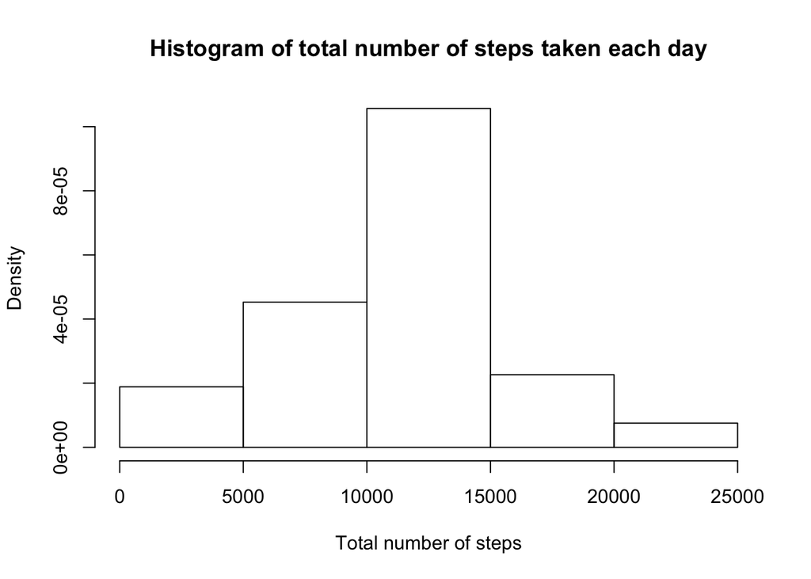

```r
hist(total$'sum(steps)', prob=TRUE, main="Histogram of total number of steps taken each day", xlab="Total number of steps")
```

3.Calculate and report the mean and median of the total number of steps taken per day

```r
mean(total$`sum(steps)`, na.rm=TRUE)
```

```
## [1] 10766.19
```

```r
median(total$`sum(steps)`, na.rm=TRUE)
```

```
## [1] 10765
```

The mean and median of the total number of steps taken per day are 10766.19 and 10765, respectively.

## What is the average daily acitivity pattern?

1. Make a time series plot of the 5-minute interval (x-axis) and the average number of steps taken, averaged across all days (y-axis)

```r
interval_average <- activity %>% group_by(interval) %>% summarise(mean_steps = mean(steps, na.rm=TRUE))
str(interval_average)
```

```
## tibble [288 × 2] (S3: tbl_df/tbl/data.frame)
##  $ interval  : int [1:288] 0 5 10 15 20 25 30 35 40 45 ...
##  $ mean_steps: num [1:288] 1.717 0.3396 0.1321 0.1509 0.0755 ...
```

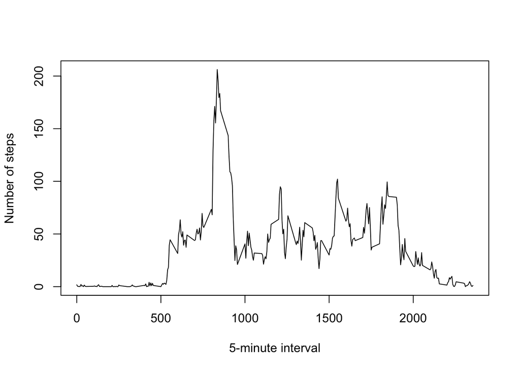

```r
plot(interval_average, type="l", xlab="5-minute interval", ylab="Number of steps")
```

2. Which 5-minute interval, on average across all the days in the dataset, contain the maximum number of steps?

```r
interval_max <- interval_average$interval[which.max(interval_average$mean_steps)]
interval_max
```

```
## [1] 835
```

The “835” 5-minute interval, on average across all the days in the dataset, contain the maximum number of steps.